# Big and Fast Data

Georgios Gousios and Burcu Kulahcioglu Ozkan

31 August 2026

# Big and Fast Data

## What is big data?

An overloaded, fuzzy term

> “Data too large to be efficiently processed on a single computer”

> “Massive amounts of diverse, unstructured data produced by high-performance applications”

## How big is “Big”?

Typical numbers associated with Big Data

Hyperscale computing: Companies such as Google, Amazon, Microsoft, and OpenAI operate globally distributed infrastructure at enormous scale, processing massive volumes of data and computation.

## How big is “Big”? – FaceBook

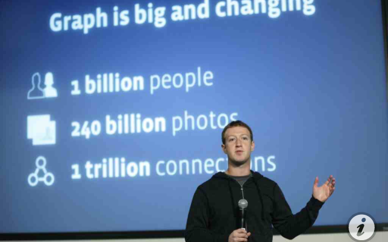

FaceBook

Numbers ($\Leftarrow$) are from 2014! [Today on FB](https://zephoria.com/top-15-valuable-facebook-statistics/):

## How big is “Big”? – Instagram

[figure not shown]

Instagram

- More than 2B daily active users, clicking around the app
- ~95M photos & videos uploaded every day
- More than 3B monthly active users
- ~686M followers for the most-followed account
- ~680M followers for the most-followed person

## How big is “Big”? – TikTok

[figure not shown]

TikTok

- ~2 Billion monthly active users
- ~1.1 billion daily active users
- ~34 million videos uploaded every day
- ~100 minutes per user per day

## How big is “Big”? – ChatGPT

[figure not shown]

ChatGPT

- 1+ billion monthly users
- ~1 billion weekly users
- ~2.5 billion prompts every day
- ~29,000 prompts every second

## The many Vs of Big data

[Main Vs](http://blogs.gartner.com/doug-laney/files/2012/01/ad949-3D-Data-Management-Controlling-Data-Volume-Velocity-and-Variety.pdf), by Doug Laney

- **Volume**: large amounts of data
- **Variety**: data comes in many different forms from diverse sources
- **Velocity**: the content is changing quickly

More Vs

- **Value**: data alone is not enough; how can value be derived from it?
- **Validity**: ensure that the interpreted data is sound, clean
- **Veracity**: can we trust the data? Does it come from reliable sources?
- **Volatility**: how long does data need to be kept for? When is it considered irrelevant?
- **Visibility**: data from diverse sources need to be stitched together
- **Virality**: how quickly data is spread and shared

## Volume

We call Big Data big because it is *really big*:

- 90% of all the data ever [was created in the last 2 years](http://www.sintef.no/en/latest-news/big-data-for-better-or-worse/)
- Every human created [at least 1.7 MB of data per second](https://techjury.net/blog/how-much-data-is-created-every-day) in 2020.
- Every day, 306.4 billion emails are sent, and 500 million Tweets are made.
- The global big data and business analytics market was valued at [$138.9 billion in 2020 and is expected to grow to $229 billion in 2025] (https://www.precisely.com/blog/big-data/quality-data-big-data-worth).

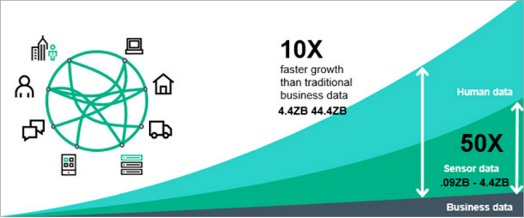

Data growth rate

## Variety

- Structured data: SQL tables, format is known
- Semi-structured data: JSON, XML
- Unstructured data: Text, audio, video

We often need to combine various data sources of different types to come up with a result

## Velocity

Data is not just big; it is generated and needs to be processed fast. Think of:

- Data centers writing to log files
- IoT sensors reporting temperatures around the globe
- Twitter: >500 million tweets a day (or 6k/sec)
- Stock Markets: high-frequency trading (latency costs money)
- Online advertising

Data needs to be processed with soft or hard real-time guarantees

## Big Data processing

- The **ETL** cycle
  - **E**xtract: Convert raw or semi-structured data into structured data
  - **T**ransform: Convert units, join data sources, cleanup etc
  - **L**oad: Load the data into another system for further processing
- Big data *engineering* is concerned with building *pipelines*
- Big data *analytics* is concerned with *discovering patterns*

## How to process all this data?

- **Batch processing**: All data exists in some data store, a program processes the whole dataset at once
- **Stream processing**: Processing of data as they arrive to the system

2 basic approaches to distribute data processing operations on lots of machines

- Divide the **data** in chunks, apply the same algorithm on all chunks (data-parallelism)
- Divide the **problem** in chunks, run it on a cluster of machines (task-parallelism)

## Desired properties of a big data processing system

- Robustness and fault-tolerance
- Low latency reads and updates
- Scalability
- Generalization
- Extensibility
- Ad hoc queries
- Minimal maintenance
- Debuggability

## Large-scale computing

Not a new discipline:

- Cray-1 appeared in the late ’70s
- Physicists used super computers for simulations in the ’80s
- Shared-memory designs still in large scale use (e.g. [TOP500 supercomputers](https://en.wikipedia.org/wiki/TOP500))

*What is new?*

Large scale processing on **distributed**, **commodity** computers, enabled by advanced **software** using **elastic** resource allocation.

Software (not HW!) is what drives the Big Data industry.

## The Big Data Tech Landscape (2019)

[figure not shown]

The big data landscape 2019

## The ML, AI & Big Data Landscape (2024)

The technology landscape changed, but the fundamental problem remains: how do we process massive amounts of distributed data efficiently and reliably?

[figure not shown]

The MAD landscape 2024

## Progress is mostly industry-driven

**D:** Most advancement in Big Data technologies came from the industry. The universities only started contributing late. Why?

. . .

[figure not shown]

Data is the new oil

## Typical problems solved with Big Data

- **Modeling**: What factors influence particular outcomes/behaviors?
- **Information retrieval**: Finding needles in haystacks, aka search engines
- **Collaborative filtering**: Recommending items based on items other users with similar tastes have chosen
- **Outlier detection**: Discovering outstanding transactions
- **Graph analytics**: Finding patterns and relationships in large networks, e.g., social networks, web graphs, recommendation networks
- **Observability and log analytics**: Processing logs, traces, and metrics to understand and monitor complex distributed systems
- **AI/LLM data processing**: Processing large collections of documents, interactions, embeddings, and evaluation data for retrieval-augmented generation, model evaluation, and AI applications

## Image credits

- Data is the new oil picture (c) the Economist

## Bibliography

[1]

J. Dean and S. Ghemawat, “[MapReduce: Simplified data processing on large clusters](http://dl.acm.org/citation.cfm?id=1251254.1251264),” in *Proceedings of the 6th conference on symposium on opearting systems design & implementation - volume 6*, 2004, pp. 10–10.

[2]

S. Ghemawat, H. Gobioff, and S.-T. Leung, “[The google file system](https://doi.org/10.1145/945445.945450),” in *Proceedings of the nineteenth ACM symposium on operating systems principles*, 2003, pp. 29–43.

[3]

G. DeCandia *et al.*, “Dynamo: Amazon’s highly available key-value store,” *ACM SIGOPS operating systems review*, vol. 41, no. 6, pp. 205–220, 2007.

[4]

M. Zaharia, M. Chowdhury, M. J. Franklin, S. Shenker, and I. Stoica, “Spark: Cluster computing with working sets.” *HotCloud*, vol. 10, no. 10–10, p. 95, 2010.

[5]

A. Krizhevsky, I. Sutskever, and G. E. Hinton, “[ImageNet classification with deep convolutional neural networks](http://papers.nips.cc/paper/4824-imagenet-classification-with-deep-convolutional-neural-networks.pdf),” in *Advances in neural information processing systems 25*, F. Pereira, C. J. C. Burges, L. Bottou, and K. Q. Weinberger, Eds. Curran Associates, Inc., 2012, pp. 1097–1105.

[6]

A. Halevy, P. Norvig, and F. Pereira, “The unreasonable effectiveness of data,” *IEEE Intelligent Systems*, vol. 24, no. 2, pp. 8–12, 2009.

## Copyright

This work is (c) 2017, 2018, 2019, 2020, 2021 - onwards by TU Delft and Georgios Gousios and licensed under the [Creative Commons Attribution-NonCommercial-ShareAlike 4.0 International](http://creativecommons.org/licenses/by-nc-sa/4.0/) license.